# Calibration Metrics for Random Forest and Generalized Linear Model Using French Insurance Data

Public liability

Calibration Metrics

France

freMPL1sub

Author

Julien Siharath

Published

October, 2024

# Introduction

**Session Settings**

```r
# Graphs----
face_text='plain'
face_title='plain'
size_title = 14
size_text = 11
legend_size = 11

global_theme <- function() {
  theme_minimal() %+replace%
    theme(
      text = element_text(size = size_text, face = face_text),
      legend.position = "bottom",
      legend.direction = "horizontal",
      legend.box = "vertical",
      legend.key = element_blank(),
      legend.text = element_text(size = legend_size),
      axis.text = element_text(size = size_text, face = face_text),
      plot.title = element_text(
        size = size_title,
        hjust = 0.5
      ),
      plot.subtitle = element_text(hjust = 0.5)
    )
}

# Outputs
options("digits" = 2)
```

**In Brief**

## Required Packages

```r
# R package required to run Python code in a Quarto document

required_R_libraries <- c(
  "CASdatasets",
  "tidyverse",
  "ranger",
  "caret",
  "locfit"
)
invisible(lapply(required_R_libraries, library, character.only = TRUE))
```

## Data

The data used in this vignette comes from a French motor third-party liability insurance portfolio. The dataset, `freMPL1sub`, is part of the CASdatasets package in RStudio and contains details about contracts and clients obtained from a French insurance company, specifically related to a motor insurance portfolio.

This dataset is a subset of several datasets, such as `freMTPL1`, `freMTPL2`, and others, all of which are available in the casdatasets package. The subset has been filtered to include only instances where the exposure is greater than 0.9, allowing for the effective application of classification trees for more precise analysis.

## Dictionaries

The list of the 18 variables from the `freMPL1sub` dataset is reported in Table 1.

Table 1: Content of the `freMPL1sub` dataset

| Attribute | Type | Description |
| --- | --- | --- |
| LicAge | Numeric | The driving licence age, in months |
| VehAge | Numeric | Age of the vehicle in years |
| sensitive | Factor | Gender of the driver |
| MariStat | Factor | Marital status of the driver |
| SocioCateg | Factor | Socio-economic category of the driver |
| VehUsage | Factor | Usage of the vehicle |
| DrivAge | Numeric | Age of the driver in years |
| HasKmLimit | boolean | Indicator if there’s a mileage limit |
| BonusMalus | Numeric | Bonus-malus coefficient |
| VehBody | Factor | Body type of the vehicle |
| VehPrice | Factor | Price category of the vehicle |
| VehEngine | Factor | Type of engine |
| VehEnergy | Factor | Type of fuel used (diesel or regular) |
| VehMaxSpeed | Factor | Maximum speed category of the vehicle |
| VehClass | Factor | Vehicle class |
| y | boolean | Response variable (if there is a claim) |
| RiskVar | Numeric | Risk variable |
| Garage | Factor | Type of garage used |

## Importation

**Code for importing the dataset**

```r
data("freMPL1sub")

CONTRACTS <- freMPL1sub

# Create factors
CONTRACTS.f <-
  CONTRACTS |>
  mutate(
    DrivAge = cut(DrivAge, c(17, 22, 26, 42, 74, Inf))
  )
```

# Purpose

In insurance modeling, the accuracy of predicted probabilities is essential for effective decision-making. Calibration is a technique used to measure how well these predicted probabilities align with actual outcomes. Perfect calibration occurs when the predicted probability of an event matches the observed frequency of that event.

Mathematically, perfect calibration can be described as:

$$\mathbb{P}(Y = 1 | \hat{p} = p) = p$$

This equation implies that for a given predicted probability $p$, the actual probability of the event $Y = 1$ should also be $p$. In other words, if a model predicts a 30% probability of an event, that event should occur 30% of the time when the predicted probability is 30%.

In the context of insurance, achieving perfect calibration is beneficial for pricing policies effectively. Accurately calibrated models ensure that the premiums set for different risk categories reflect the true probabilities of claims occurring. For instance, if a model predicts a 60% chance of claims for a specific group, but the actual claim rate is significantly lower, it may lead to overpricing, driving away potential customers. Conversely, if the predicted probability is too low, insurers may underprice their products, risking financial losses when claims exceed expectations.

By ensuring that predicted probabilities are well-calibrated, insurers can make more informed pricing decisions, leading to a more competitive and sustainable pricing strategy. This not only enhances profitability but also helps maintain trust with policyholders, as fair pricing reflects accurate assessments of risk.

In this vignette, we evaluate the calibration of two models commonly applied in insurance risk prediction: a Generalized Linear Model (GLM) and a Random Forest. We aim to assess how accurately these models predict the likelihood of insurance claims using the following methods:

- **Brier Score**: This metric evaluates the accuracy of probabilistic predictions by measuring the average squared difference between predicted probabilities and actual outcomes. A lower Brier score indicates better model performance (**brier1950verification?**).
- **Expected Calibration Error (ECE)**: ECE is a metric that quantifies the average deviation between predicted probabilities and actual outcomes across all instances. It is calculated by taking the weighted average of the absolute differences between predicted probabilities and observed frequencies, across all probability bins. The ECE provides a summary measure of calibration that is particularly useful when comparing different models. A lower ECE indicates better calibration, signifying that the predicted probabilities are closer to the actual event rates.
- **Reliability Diagrams**: Reliability Diagrams with Locfit Smoothing: These diagrams visually represent model calibration by plotting predicted probabilities against observed frequencies (**degroot1983comparison?**). A perfectly calibrated model will have points lying along the diagonal, indicating that predicted probabilities match actual outcomes. Any deviations from this line show whether the model overestimates or underestimates probabilities.

To generate these reliability diagrams, we apply locfit smoothing (**loader1999local?**). Locfit is a non-parametric technique that produces flexible, locally weighted regression curves, smoothing out noise in the data and providing a refined calibration curve. By using locfit, we ensure that random fluctuations in the data do not obscure the true calibration performance, offering a clearer representation of how well the models align predicted probabilities with actual outcomes.

This vignette shows how calibration assesses whether predicted probabilities match actual outcomes, identifying if a model consistently overestimates or underestimates risk, which ultimately influences prediction-based decision-making.

For an exploration of the limitations of calibration metrics, refer to (**fernandes2024probabilistic?**), which highlights the necessity for recalibration methods discussed in (**machado2024uncertainty?**).

# Methods

## Random Forest Model

Random Forest, as described in Breiman (2001), is a versatile machine learning technique that belongs to a class of ensemble learning methods. In this method, multiple decision trees are constructed during training, and their predictions are combined to produce a more accurate and stable model. Specifically, predictions are averaged for regression tasks and voted on for classification tasks.

The key idea behind Random Forest is to build a “forest” of decision trees, where each tree is trained on a random subset of the data and a random subset of the features. This randomness makes the model more robust and less prone to overfitting, which is a common issue with individual decision trees.

The process of building a Random Forest can be summarized in the following steps:

1. **Bootstrap Sampling**: Multiple subsets of the original dataset are created using bootstrapping, which involves randomly selecting samples with replacement.
2. **Random Feature Selection**: At each node of the tree, a random subset of features is selected, and the best feature from this subset is used to split the data.
3. **Tree Construction**: Decision trees are constructed for each bootstrap sample, and these trees grow without pruning, resulting in very deep and complex structures.
4. **Aggregation**: For regression tasks, predictions from all trees are averaged. For classification tasks, the most frequent prediction (mode) is selected.

The Random Forest model can be mathematically represented as:

$$\hat{y}_i = \frac{1}{T} \sum_{t=1}^{T} f_t(x_i)$$

where $\hat{y}_i$ is the predicted value for the $i^{th}$ observation, $T$ is the total number of trees, and $f_t(x_i)$ represents the prediction of the $t^{th}$ tree.

One of the key advantages of Random Forest is its ability to handle large datasets with high dimensionality and missing data. The random selection of features at each split ensures that the model doesn’t rely too heavily on any single feature, reducing the risk of overfitting. Additionally, Random Forest provides a measure of **feature importance**, ranking the contribution of each feature to the model’s predictive power. This is particularly useful for understanding which features are most influential in making predictions.

In conclusion, Random Forest is widely appreciated for its high accuracy, robustness, and ease of use. It is highly effective for both regression and classification tasks and is especially valuable in situations with a large number of features or complex relationships between variables. For additional information, see Breiman (2001).

## Generalized Linear Model (GLM)

A Generalized Linear Model (GLM), first formalized by (**nelder1972generalized?**), extends the linear model to allow for non-normal response variables. GLMs are widely used in insurance for modeling claims data, where the response variable might follow distributions such as Poisson or binomial.

GLMs consist of three main components, each playing a critical role in how the model relates the predictor variables to the response variable:

1. **Random Component**: This specifies the probability distribution of the response variable. In GLMs, the response variable $y_i$ is not assumed to be normally distributed, as it is in linear regression. Instead, the response can follow a variety of distributions from the exponential family, such as Poisson, binomial, or gamma. The choice of distribution depends on the nature of the outcome (e.g., count data, binary outcomes).
2. **Systematic Component**: This represents the linear predictor, which is a linear combination of the explanatory variables (predictors). Formally, it is expressed as:

$$\eta_i = x_i^T \beta$$

where $x_i$ is a vector of the explanatory variables for observation $i$, and $\beta$ is a vector of coefficients. The linear predictor $x_i^T \beta$ is the part of the model that combines the covariates to explain the variation in the response variable. This is similar to how a linear regression model operates but in the GLM, the connection between the linear predictor and the response is mediated by the link function.

3. **Link Function**: The link function $g(\cdot)$ provides the bridge between the linear predictor and the mean of the response variable, $\mathbb{E}(y_i|x_i)$. It transforms the expected value of the response so that it can be modeled as a linear function of the predictors. The choice of link function depends on the distribution of the response. For example, a log link function is commonly used for count data (e.g., Poisson regression), and a logit link function is often used for binary outcomes (e.g., logistic regression).

The GLM model can be expressed as:

$$g(\mathbb{E}(y_i|x_i)) = x_i^T \beta$$

where $g(\cdot)$ is the link function, $x_i^T \beta$ is the linear predictor, and $\mathbb{E}(y_i|x_i)$ is the expected outcome for observation $i$.

## Extended Calibration Error (ECE)

Extended Calibration Error (ECE) is a metric used to evaluate the calibration of probabilistic predictions, especially in the context of insurance claims modeling. It quantifies the discrepancy between predicted probabilities and observed outcomes, providing insights into the reliability of a predictive model. ECE is particularly useful for assessing models that output probabilities, as it highlights potential biases in the predicted probabilities.

1. **Definition**: ECE is defined as the weighted average of the absolute differences between predicted probabilities and observed frequencies of events. Formally, it is expressed as:

   $$\text{ECE} = \sum_{b=1}^B \frac{n_b}{n} \left| \text{P}_{\text{avg},b} - \text{O}_{\text{avg},b} \right|$$

## Brier Score

The Brier Score is a well-known metric for assessing the accuracy of probabilistic predictions. It is particularly useful in the insurance domain for evaluating the predictive performance of models that output probabilities of events, such as claim occurrences.

1. **Definition**: The Brier Score is defined as the mean squared difference between predicted probabilities and the actual binary outcomes. It can be expressed mathematically as:

   $$\text{Brier Score} = \frac{1}{N} \sum_{i=1}^N (f_i - o_i)^2$$

   where $N$ is the number of observations, $f_i$ is the predicted probability of the event for observation $i$, and $o_i$ is the actual outcome (1 if the event occurred, 0 otherwise).
2. **Interpretation**: The Brier score ranges from 0 to 1 it measures the mean squared difference between predicted probabilities and actual outcomes. A lower Brier score indicates better calibration.

## Reliability Diagram with Locfit Smoothing

The Reliability Diagram is a graphical representation used to assess the calibration of probabilistic predictions visually. It plots the predicted probabilities against the observed frequencies of events, providing insights into how well the model calibrates its probability outputs.

1. **Construction**: To construct a Reliability Diagram, predicted probabilities are binned, and the average predicted probability and observed frequency are calculated for each bin. This is typically plotted as a scatter plot of predicted probabilities versus observed proportions.
2. **Locfit Smoothing**: To enhance the visual interpretation of the Reliability Diagram, Locfit smoothing can be applied. Locfit is a local regression method that fits a smooth curve to the binned data, making it easier to identify trends and deviations from perfect calibration (the 45-degree line).

   $$\text{Locfit}(\hat{p}_b) = \sum_{j=1}^B w_{ij} y_j$$

# Calibration Evaluation

### Data preprocessing

We split the data into training and calibration sets. The training set is utilized to fit the models, while the calibration set is used for the calibration process.

**Splitting Data into Training and Calibration Sets**

```r
set.seed(23)

trainIndex <- createDataPartition(CONTRACTS.f$y, p = 0.5,
                                  list = FALSE,
                                  times = 1)

dataTrain <- CONTRACTS.f[trainIndex, ]  # Training set
dataCalibration <- CONTRACTS.f[-trainIndex, ]  # Calibration set

dataTrain$y <- as.numeric(as.character(dataTrain$y))

dataCalibration$y <- as.numeric(as.character(dataCalibration$y))
```

### Training the RandomForest Model

```r
rf_model <- ranger(y ~.,
                   num.trees = 500,   # Number of trees
                   mtry = 2,          # Number of features to try at each split
                   min.node.size = 1, # Minimum size of terminal nodes
                   importance = 'impurity',
                   data = dataTrain,
                   write.forest = TRUE)
```

### Training the GLM Model

```r
glm_model <- glm(y ~., data = dataTrain, family = binomial)
```

## Calibration Metrics

**Brier Score**

```r
#
# Make predictions for both models
dataCalibration$rf_pred_prob <- predict(rf_model, dataCalibration)$predictions
dataCalibration$glm_pred_prob <- predict(glm_model, dataCalibration,type = "response")

# Calculate Brier Score for Random Forest model
brier_rf <- mean((dataCalibration$rf_pred_prob - dataCalibration$y)^2)

# Calculate Brier Score for GLM model
brier_glm <- mean((dataCalibration$glm_pred_prob - dataCalibration$y)^2)
```

The brier score for the random forest model is 0.07  
The brier score for the glm model is 0.08

**ECE**

```r
# Function to calculate ECE
calculate_ece <- function(predictions, actuals, n_bins = 10) {
  # Create bins
  bins <- seq(0, 1, length.out = n_bins + 1)
  bin_means <- numeric(n_bins)
  bin_obs <- numeric(n_bins)
  bin_counts <- numeric(n_bins)

  for (i in 1:n_bins) {
    # Find indices of predictions in the current bin
    in_bin <- predictions >= bins[i] & predictions < bins[i + 1]
    bin_counts[i] <- sum(in_bin)

    # Avoid division by zero
    if (bin_counts[i] > 0) {
      bin_means[i] <- mean(predictions[in_bin], na.rm = TRUE)
      bin_obs[i] <- mean(actuals[in_bin], na.rm = TRUE)
    }
  }

  # Calculate ECE
  ece <- sum(bin_counts / sum(bin_counts) * abs(bin_means - bin_obs), na.rm = TRUE)
  return(ece)
}


# Calculate ECE for GLM model
ece_glm <- calculate_ece(dataCalibration$glm_pred_prob, dataCalibration$y)
ece_rf <- calculate_ece(dataCalibration$rf_pred_prob, dataCalibration$y)
```

The ECE for the random forest model is 0.03  
The ECE for the glm model is 0.01

# Visualizations

**Reliability Diagram for the Random Forest**

**Code for the reliability diagram function**

```r
# Function to create a reliability diagram with locfit smoothing

create_reliability_diagram <- function(data, pred_col, obs_col, n_bins = 10) {
  # Create bins for predicted probabilities
  data$bin <- cut(data[[pred_col]], breaks = seq(0, 1,
                                                 length.out = n_bins + 1),
                                                 include.lowest = TRUE)

  # Calculate mean predicted and actual probabilities per bin
  bin_summary <- data %>%
    group_by(bin) %>%
    summarise(
      mean_pred_prob = mean(get(pred_col)),
      mean_obs_prob = mean(get(obs_col)),
      n = n(),
      .groups = 'drop'
    )

  # Use locfit to smooth the observed probabilities based on predicted probabilities
  fit_locfit <- locfit(mean_obs_prob ~ mean_pred_prob,
                       data = bin_summary,
                       weights = bin_summary$n)

  # Generate smoothed probabilities for plotting
  smooth_obs_prob <- predict(fit_locfit, newdata = bin_summary$mean_pred_prob)

  # Plot the reliability diagram
  ggplot(bin_summary, aes(x = mean_pred_prob)) +
    geom_point(aes(y = mean_obs_prob), color = "#1E88E5", size = 3) +
    geom_line(aes(y = smooth_obs_prob), color = "red", linewidth = 1) +
    geom_abline(slope = 1, intercept = 0, linetype = "dashed", color = "gray") +  # 45-degree reference line
    labs(
      title = "Reliability Diagram with Locfit Smoothing",
      x = "Mean Predicted Probability",
      y = "Mean Observed Probability"
    ) +
    global_theme() +
    coord_fixed(ratio = 1) +
    xlim(0, 1) +
    ylim(0, 1)
}
```

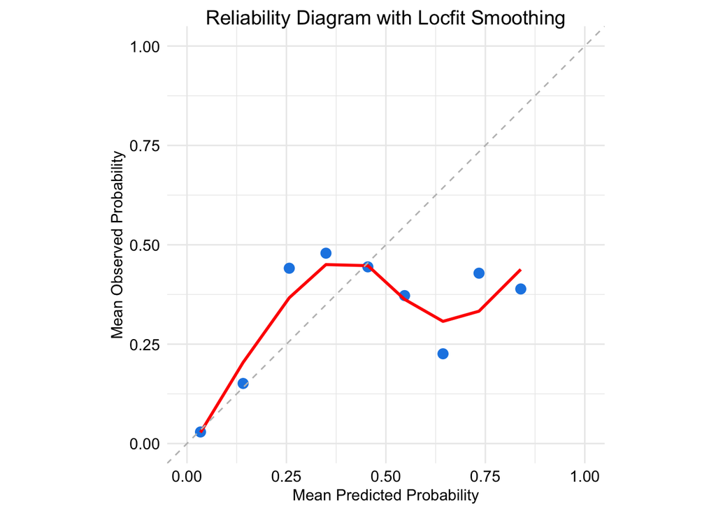

```r
p <- create_reliability_diagram(dataCalibration, "rf_pred_prob", "y", n_bins = 10)
print(p)
```

**Reliability Diagram for the GLM Model**

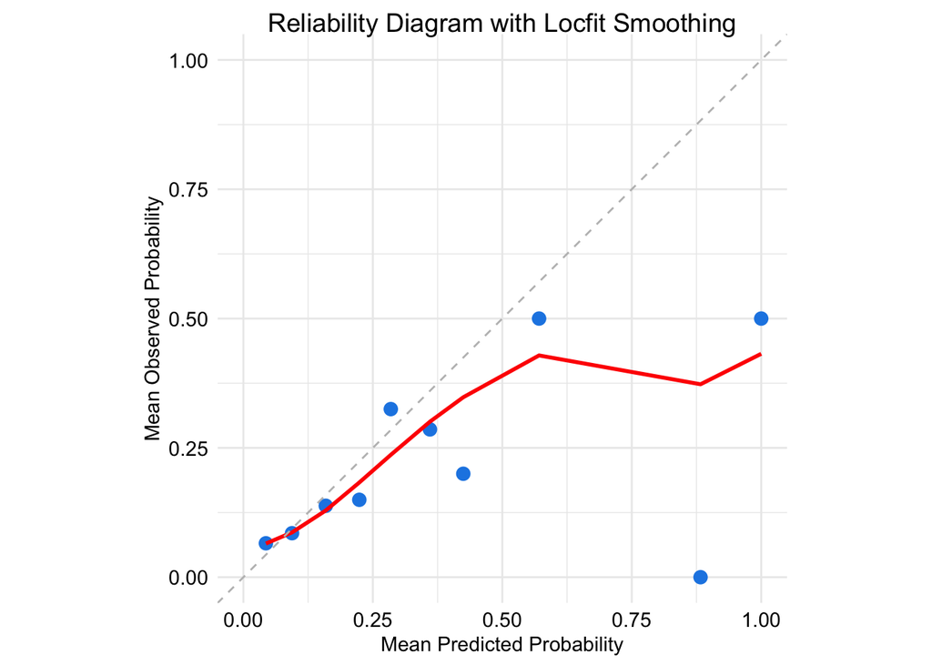

```r
p <- create_reliability_diagram(dataCalibration, "glm_pred_prob", "y", n_bins = 15)

print(p)
```

# References

Breiman, Leo. 2001. “Random Forests.” *Machine Learning* 45: 5–32.

# See also

For additional datasets with similar occurrence structures, see [`credit`](https://dutangc.github.io/CASdatasets/reference/credit.html) (import with `data("credit")`): German Credit dataset, or [`uslapseagent`](https://dutangc.github.io/CASdatasets/reference/uslapseagent.html): United States lapse dataset from tied-agent channel (import with `data("uslapseagent")`),